# March Madness ML

Richard Hardis, Arjun Goyal, Fred Sackfield, Anthony Temeliescu

3/19/2020

# Report

## Data Collection

The main portion of our data is taken from the Kaggle dataset called College Basketball Dataset by Andrew Sundberg (https://www.kaggle.com/andrewsundberg/college-basketball-dataset#cbb.csv). It contains data on 24 different variables measuring relevant team performance metrics such as adjusted tempo, tournament seed, and defensive rebound percentage. In total, the dataset contains 1757 rows and includes 5 seasons of data from 2015 to 2019. A driving motivation of the project is to work with novel or unconventional data points to explore alternate angles of predicting NCAA tournament performance. To this end, we treated the kaggle dataset as our “base” set, which we then looked to supplement with additional features.

For these additional features, we came up with ideas for quantitative data points that we believed could be useful in predicting post-season performance. One such feature that we added is regular season performance against the spread (ATS). We believe this data point is not widely used in other NCAA tournament modeling efforts, and it provides an interesting perspective on a team’s regular season performance based on market expectations. Another feature that we added was coach’s past performance, both in regular season wins and tournament wins. We believe that a coach’s pedigree and past tournament performance could be a significant factor in tournament performance.

We wrote Python web scraping programs to collect ATS data and coaching data from Covers.com and KenPom.com, respectively. These scripts imported the new data into a SQL database, where the data was then cleaned and integrated with our base set from Kaggle. The resulting “full” dataset was then exported from SQL into a csv file, which will be used for the rest of the analysis below.

## Data Exploration

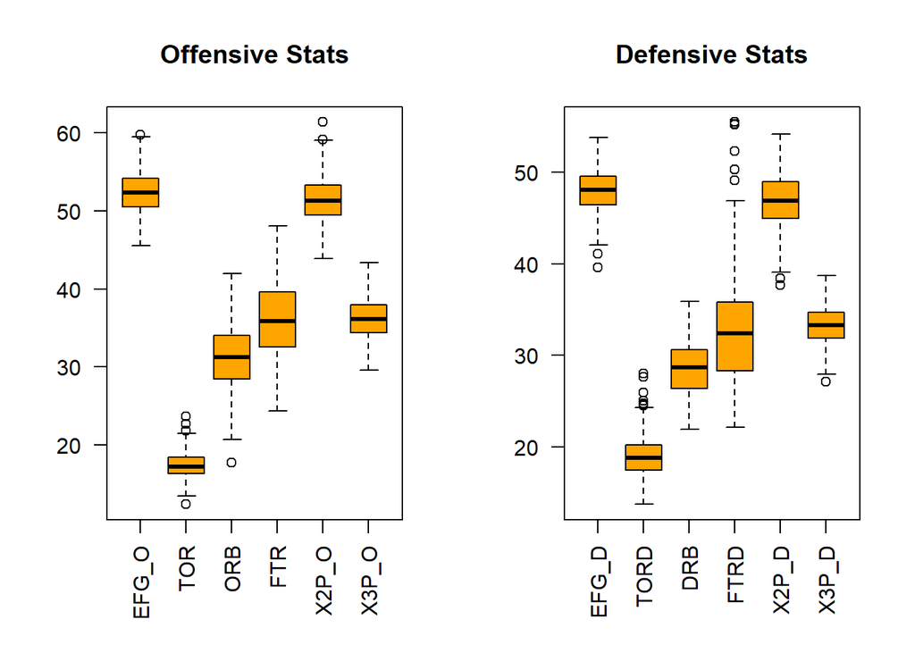

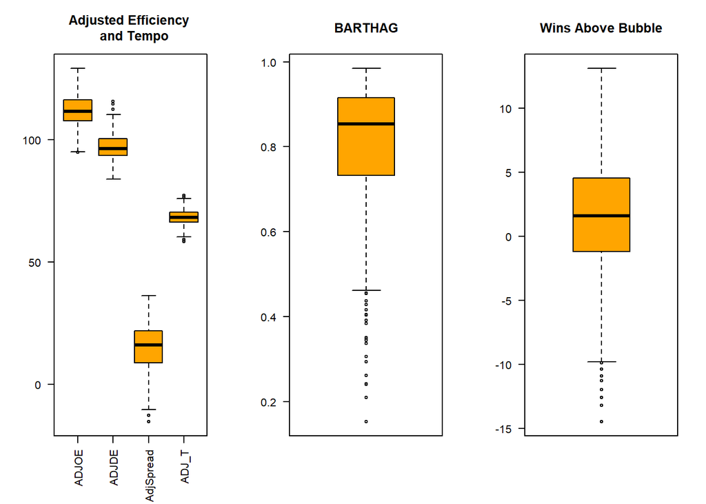

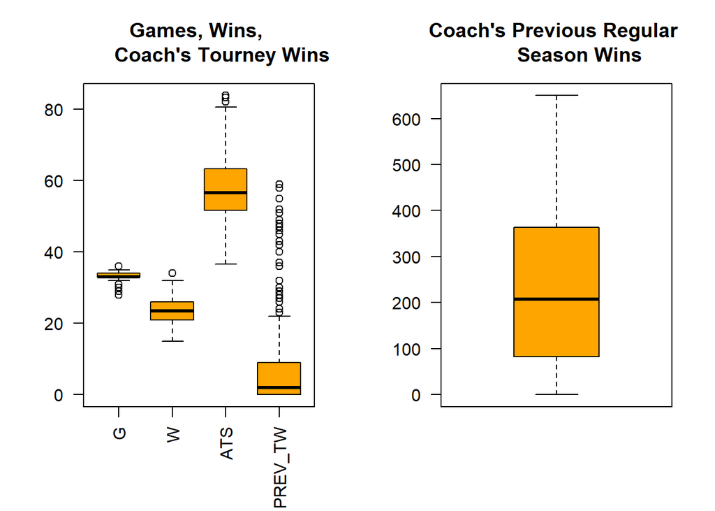

The offensive percentage statistics were analyzed separately from the defensive percentage statistics to view outliers and trends. We see one team that shot at a higher field goal percentage (EFG_O) of 60% compared to other teams. There are a few teams that had a higher turnover rate (TOR) closer to 25% compared to themedian. ONe team had a significantly lower offensive rebound percentage (ORB), under 20%, compared to the median near 30%. The median two-point shooting percentage (X2P_0) is near 50% while two teams shot closer to 60%. We see that on defense, there were a few teams that caused more turnovers (TORD) compared to the median. While the median free throw rate allowed (FTRD) was near 30%, 6 teams allowed much higher rates near 50-55%. Two teams were good defenders against the two-point shooting of their opponents (X2P_D), only allowing under 40% compared to the median closer to 50%.

Most teams that qualify for the tournament play and win roughly the same amount of games during the season. Some teams achieve a higher ATS score than the median since the tournament frequently sees lower-seeded teams advance against the odds. We see that the median number a coach’s previous tournament wins (PREV_TW) is near 0, however there are a few teams who possess coaches with 20-60 games of winning experience in the tournament. A coach’s previous regular season wins sits at a median of 200 with no outliers indicated.

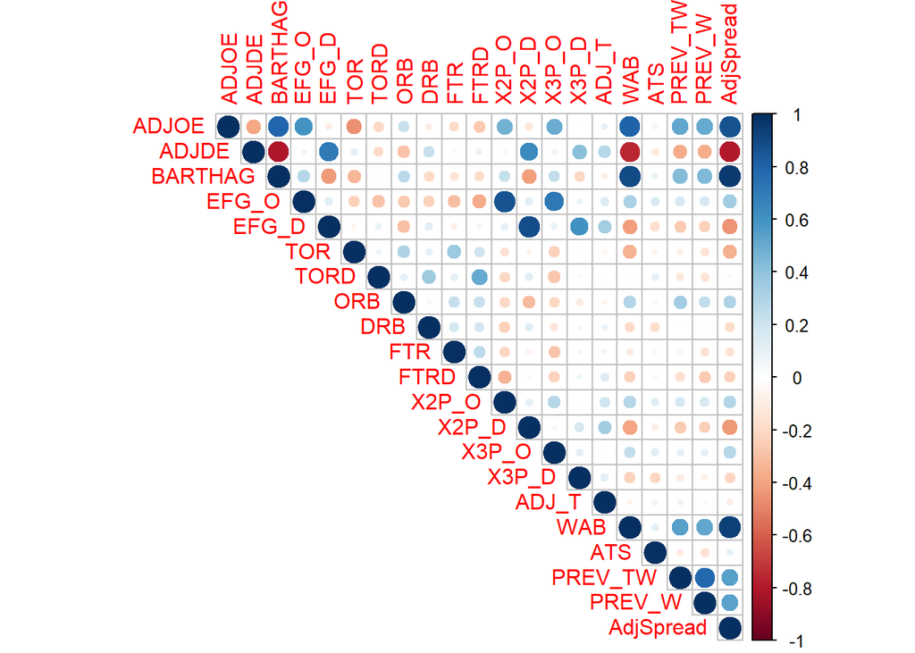

## Clustering

In the spirit of better understanding which team qualities correspond to higher chances of success, we can use clustering methods to group teams together based on similar metrics. We use the most common clustering technique, which is K-Means clustering. K-Means clustering starts with a supplied parameter k to specify the number of clusters we want to group the data into. A small set of data points are chosen randomly to serve as the “initial” cluster centers. The k-means algorithm then iterates through the dataset, calculates the Euclidean distance between each point and the k cluster centers, assigns the new point to the closest cluster, and then recalculates the cluster centers after each data point is added.

One important consideration with clustering is to avoid the “curse of dimensionality”. In other words, we should be selective in what features we use for clustering because distance-based algorithms suffer when number of features increases. So we have a few options:

1. use domain knowledge to pick out relevant and non-redundant features; this allows for better interpretability because original features are preserved
2. correlation-based selection, i.e. eliminate variables from pairs of correlated ones; this is more systematic, and still preserves features
3. do PCA first before clustering; this is more efficient for the task at hand, but takes away from interpretability

Since we prefer interpretability of our model, we’ll choose a combination of options a and b. First we’ll use domain knowledge to pick out features we think are relevant and not redundant. The hand-picked features are a reduced subset of the gameplay metrics, including off/def efficiency, orebs, 3pt, turnovers, free throws, and experience. We can also look at the reduced set of variables on the correlation matrix above to see if any others need to be removed.

As we can see from the correlation matrix, none of the remaining variables have a high correlation, so we can proceed with clustering using the selected subset of features. As mentioned above, the k-means algorithm needs a parameter k to specify the number of clusters. To determine the optimal number of clusters to group our data into, we can plot the within-cluster sum of squared errors as a function of k. The optimal k value should be at the “elbow point”: where the marginal decrease of within SSE levels off. However, based on the plot below, there isn’t a clear elbow point, so we’ll try clustering with both k=3 and k=4.

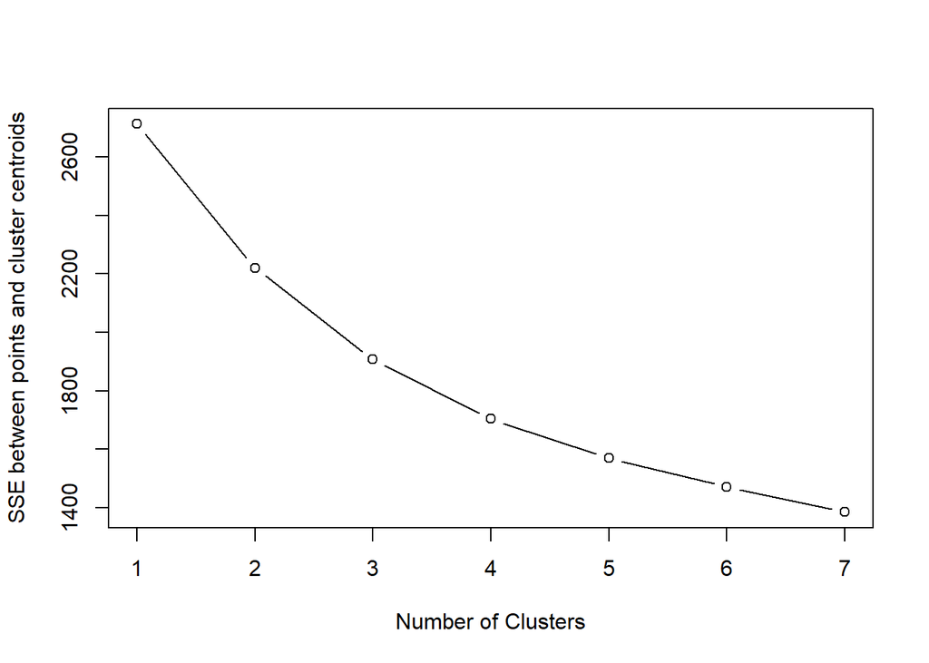

Below are the PCA-reduced cluster visualizations generated from the kmeans algorithm with k = 3 and k = 4. If we have a priori or historical knowledge about different basketball teams over the past five years, we can visually inspect the plots to either confirm or question previously held beliefs about similar-style basketball teams. For example, we can see that the 2016-2019 Virginia basketball teams are all located closely together in the same cluster. This confirms our previously held belief that coach Tony Bennett instills a distinct and consistent style of play that is different from most other basketball teams.

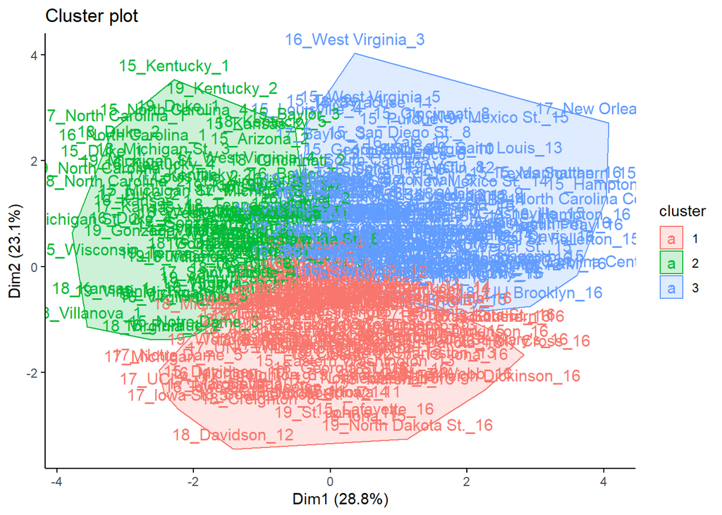

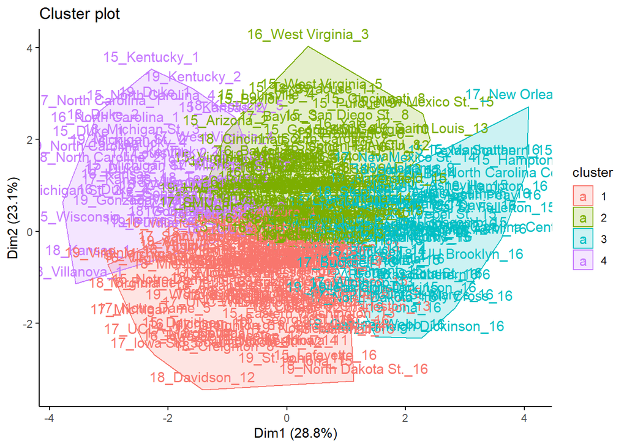

## Methods

```
##                                  Lasso Ridge   MLR  MARS Boosting Random Forest
## MSE                              0.850 0.862 0.869 0.873    0.872         0.887
## +/- 0.5 Game Prediction Accuracy 0.524 0.478 0.487 0.577    0.469         0.498
```

## Results

It can be seen from the above table that the best model by MSE score was Lasso Regression. Lasso also has the second highest accuracy after MARS and is still above 50% accurate as measured by the custom metric. Due to its high sores in both measurement categories, LASSO Regression was chosen as the model type for the final predictions. It should be noted that the accuracy of this model for predicting any given team’s tournament wins is barely above 50%, only slightly above random guessing. In fact, when our model was used to generate a predicted winners bracket for the 2019 tournament and compared against the actual results it could be seen that most of the games that our model incorrectly predicted were cases where the two teams were extremely evenly matched measured by predicted wins. Either team could have won the game that day and that is what makes March Madness simultaneously so entertaining and so difficult to predict. Further insights can be derived from the final LASSO model trained on the full dataset to inform game predictions and coaching changes. The coefficients for the model are found in the output below.

```
## 58 x 1 sparse Matrix of class "dgCMatrix"
##                     s0
## CONFA10   -0.144295030
## CONFACC    .
## CONFAE     0.182600858
## CONFAmer  -0.466863604
## CONFASun   .
## CONFB10    0.014847845
## CONFB12   -0.305631724
## CONFBE    -0.207853281
## CONFBSky   .
## CONFBSth   0.013218517
## CONFBW     0.274734295
## CONFCAA   -0.041540514
## CONFCUSA   0.638741376
## CONFHorz   .
## CONFInd    .
## CONFIvy    .
## CONFMAAC   .
## CONFMAC    .
## CONFMEAC   0.077063789
## CONFMVC    0.396312381
## CONFMWC    .
## CONFNEC    .
## CONFOVC   -0.004373220
## CONFP12    0.110873001
## CONFPat    0.029838582
## CONFSB     0.040579469
## CONFSC    -0.077555820
## CONFSEC   -0.076160095
## CONFSlnd  -0.186277642
## CONFSum    0.113752181
## CONFSWAC   .
## CONFWAC   -0.061907330
## CONFWCC    .
## G         -0.090353866
## W          0.118736896
## ADJOE      .
## ADJDE     -0.265246027
## BARTHAG   -1.333575450
## EFG_O      .
## EFG_D      .
## TOR        .
## TORD       0.002549818
## ORB       -0.015839438
## DRB        0.182924633
## FTR       -0.046822025
## FTRD      -0.015002928
## X2P_O      0.084858194
## X2P_D      0.107538904
## X3P_O     -0.089446394
## X3P_D      0.033550650
## ADJ_T     -0.012328902
## WAB       -0.021770785
## SEED      -0.012484830
## YEAR       .
## ATS       -0.070640168
## PREV_TW    0.077596810
## PREV_W     0.052858023
## AdjSpread  1.882029552
```

The two most important factors were Adjusted Spread and BARTHAG. Adjusted spread, the difference between a team’s offensive and defensive efficiency, scores teams that are excellent on offense and defense more than teams that only excel in one of the two areas. BARTHAG, or the probability of a team beating a statistically “average” NCAA Division I team in a single game, has a strong negative effect on predicted wins. This is surprising as one would expect a team with a better probability of winning against an average team to perform better in the tournament. This, however, is not the case in the LASSO model fitted to the data. It seems that the artificial BARTHAG measurement does not correspond with winning in the presence of the other included factors. Other important factors include Adjusted Defensive Efficiency, Defensive Rebounding Rate, wins, and conference.

## Conclusions

In the future, these modeling techniques can be expanded upon and improved. More granular data such as player level statistics and composition of team positions could be added. More data beyond 5 years of tournaments would also help reduce the variance of this model. There are two different ways this model could be extended. The first direction uses the same target variable: number of tournament wins. This choice of target variable reflects on the whole how good a given team is in a year and how well that performance is expected to translate into tournament play. This is a more general measure of success. The other, more specific method, is to predict a tournament’s outcome game by game. This would require more granular data and relies on predicting outcomes of specific head-to-head matchups between two different teams. The seeding and order of games played has a much greater effect on this method’s predictions than using the tournament wins prediction method. Both are useful. A coach may be more interested in how generally good his or her team is heading into a tournament or when recruiting specific types of players to improve important metrics such as defensive rebounding or offensive efficiency. Someone who is betting on a March Madness bracket may be more intersted in the game-by-game winner prediction modeling technique as it forecasts a single specific bracket outcome. Overall, the pursuit of better NCAA Tournament win predictions is important to fans and coaching staff alike. Even though the crystal ball of perfect win prediction remains elusive, better data and analytical techniques are bringing that closer to reality.